# Убытки развлекательного приложения Procrastinate Pro+

**Описание:** Несмотря на огромные вложения в рекламу, последние несколько месяцев компания терпит убытки. Наша задача — разобраться в причинах и помочь компании выйти в плюс.

**Цель исследования**

- откуда приходят пользователи и какими устройствами они пользуются,
- сколько стоит привлечение пользователей из различных рекламных каналов;
- сколько денег приносит каждый клиент,
- когда расходы на привлечение клиента окупаются,
- какие факторы мешают привлечению клиентов.

**Входные данный**

- `visits_info_short.csv` - информация о посещениях сайта
- `orders_info_short.csv` - информацию о заказах
- `osts_info_short.csv` - информацию о расходах на рекламу

**Ход исследования**

1. **Обзор данных.** Мы проведем загрузку и обзор предоставленных данных. 1.1 *Предобработка данных.*
2. **Зададим функции для расчёта и анализа LTV, ROI, удержания и конверсии.**
3. **Проведем иследовательский анализ данных.**
4. **Маркетинг**
5. **Оценим окупаемость рекламы**
6. **Вывод**

### Обзор данных.

Загружаем данные и подготовим их к анализу.

Загрузите данные о визитах, заказах и рекламных расходах из CSV-файлов в переменные.

**Пути к файлам**

- визиты: `/datasets/visits_info_short.csv`. [Скачать датасет](https://code.s3.yandex.net/datasets/visits_info_short.csv);
- заказы: `/datasets/orders_info_short.csv`. [Скачать датасет](https://code.s3.yandex.net/datasets/orders_info_short.csv);
- расходы: `/datasets/costs_info_short.csv`. [Скачать датасет](https://code.s3.yandex.net/datasets/costs_info_short.csv).

Изучите данные и выполните предобработку. Есть ли в данных пропуски и дубликаты? Убедитесь, что типы данных во всех колонках соответствуют сохранённым в них значениям. Обратите внимание на столбцы с датой и временем.

### Импорт библиотек и загрузка данных

`pandas` - для загрузки и обработки данных мы воспльзуемся библеотекой .

`matplotlib` - для работы с минимальным и максимальным желаемые значения для графиков.

`datetime` - библиотека для работой с датой

`numpy` - библиотека высокоуровневых математических функций

```python
import pandas as pd
import numpy as np
from datetime import datetime, timedelta
from matplotlib import pyplot as plt
```

### Загрузим файлы из папки /datasets и сохраним в переменные

Выведем первые 5 строк таблиц и общую информацию:

```python
try:
    sessions = pd.read_csv('/datasets/visits_info_short.csv')
    orders = pd.read_csv('/datasets/orders_info_short.csv')
    ad_costs = pd.read_csv('/datasets/costs_info_short.csv')
    display('Загрузка онлайн')
except:
    sessions = pd.read_csv('datasets/visits_info_short.csv')
    orders = pd.read_csv('datasets/orders_info_short.csv')
    ad_costs = pd.read_csv('datasets/costs_info_short.csv')
    display('Загрузка офлайн')

display(
    sessions.head(5),
    orders.head(5),
    ad_costs.head(5)
)
```

```
'Загрузка офлайн'
```

|  | User Id | Region | Device | Channel | Session Start | Session End |
| --- | --- | --- | --- | --- | --- | --- |
| 0 | 981449118918 | United States | iPhone | organic | 2019-05-01 02:36:01 | 2019-05-01 02:45:01 |
| 1 | 278965908054 | United States | iPhone | organic | 2019-05-01 04:46:31 | 2019-05-01 04:47:35 |
| 2 | 590706206550 | United States | Mac | organic | 2019-05-01 14:09:25 | 2019-05-01 15:32:08 |
| 3 | 326433527971 | United States | Android | TipTop | 2019-05-01 00:29:59 | 2019-05-01 00:54:25 |
| 4 | 349773784594 | United States | Mac | organic | 2019-05-01 03:33:35 | 2019-05-01 03:57:40 |

|  | User Id | Event Dt | Revenue |
| --- | --- | --- | --- |
| 0 | 188246423999 | 2019-05-01 23:09:52 | 4.99 |
| 1 | 174361394180 | 2019-05-01 12:24:04 | 4.99 |
| 2 | 529610067795 | 2019-05-01 11:34:04 | 4.99 |
| 3 | 319939546352 | 2019-05-01 15:34:40 | 4.99 |
| 4 | 366000285810 | 2019-05-01 13:59:51 | 4.99 |

|  | dt | Channel | costs |
| --- | --- | --- | --- |
| 0 | 2019-05-01 | FaceBoom | 113.3 |
| 1 | 2019-05-02 | FaceBoom | 78.1 |
| 2 | 2019-05-03 | FaceBoom | 85.8 |
| 3 | 2019-05-04 | FaceBoom | 136.4 |
| 4 | 2019-05-05 | FaceBoom | 122.1 |

В названиях колонок присутствует нарушения стиля, приведем все к нижнему регистру и заменим пробел на нижнее подчеркивание.

```python
def str_lower(df): #Сделаем функцию для поправки названий колонок таблиц
    for i in range(len(df.columns)):
        df.columns = df.columns.str.replace(' ', '_') #Заменяем пробел на _
        df.columns = df.columns.str.lower() #Приводим все к нижнему регистру
    return df

#Вызовим функцию для каждой таблице
str_lower(sessions)
str_lower(orders)
str_lower(ad_costs)

#Выведем на экран список названая колонок таблиц
print(sessions.columns)
print(orders.columns)
print(ad_costs.columns)
```

```
Index(['user_id', 'region', 'device', 'channel', 'session_start',
       'session_end'],
      dtype='object')
Index(['user_id', 'event_dt', 'revenue'], dtype='object')
Index(['dt', 'channel', 'costs'], dtype='object')
```

Проверим на пропуски:

```python
print(sessions.isna().sum())
print(orders.isna().sum())
print(ad_costs.isna().sum())
```

```
user_id          0
region           0
device           0
channel          0
session_start    0
session_end      0
dtype: int64
user_id     0
event_dt    0
revenue     0
dtype: int64
dt         0
channel    0
costs      0
dtype: int64
```

Отлично переходим дальше.

Преобразуем данные о времени для дальнейшей работы, после выведим для проверки типы данных таблиц.

```python
# преобразование данных о времени
sessions['session_start'] = pd.to_datetime(sessions['session_start'])
sessions['session_end'] = pd.to_datetime(sessions['session_end'])
orders['event_dt'] = pd.to_datetime(orders['event_dt'])
ad_costs['dt'] = pd.to_datetime(ad_costs['dt']).dt.date

print(sessions.dtypes)
print(orders.dtypes)
print(ad_costs.dtypes)
```

```
user_id                   int64
region                   object
device                   object
channel                  object
session_start    datetime64[ns]
session_end      datetime64[ns]
dtype: object
user_id              int64
event_dt    datetime64[ns]
revenue            float64
dtype: object
dt          object
channel     object
costs      float64
dtype: object
```

Посмотрим на количество полных дубликатов:

```python
print(sessions.duplicated().sum())
print(orders.duplicated().sum())
print(ad_costs.duplicated().sum())
```

```
0
0
0
```

Проверим пересечения значений колонки `channel` в таблицах `sessions` и `ad_costs`:

```python
set(sessions.channel) - set(ad_costs.channel)
```

```
{'organic'}
```

Нет только значения `organic` что логично так как это бесплатно привлеченные клиенты.

### Зададим функции для расчёта и анализа LTV, ROI, удержания и конверсии.

Это функции для вычисления значений метрик:

- `get_profiles()` — для создания профилей пользователей,
- `get_retention()` — для подсчёта Retention Rate,
- `get_conversion()` — для подсчёта конверсии,
- `get_ltv()` — для подсчёта LTV.

```python
# функция для создания пользовательских профилей

def get_profiles(sessions, orders, events, ad_costs, event_names=[]):

    # находим параметры первых посещений
    profiles = (
        sessions.sort_values(by=['user_id', 'session_start'])
        .groupby('user_id')
        .agg(
            {
                'session_start': 'first',
                'channel': 'first',
                'device': 'first',
                'region': 'first',
            }
        )
        .rename(columns={'session_start': 'first_ts'})
        .reset_index()
    )

    # для когортного анализа определяем дату первого посещения
    # и первый день месяца, в который это посещение произошло
    profiles['dt'] = profiles['first_ts'].dt.date
    profiles['month'] = profiles['first_ts'].astype('datetime64[M]')

    # добавляем признак платящих пользователей
    profiles['payer'] = profiles['user_id'].isin(orders['user_id'].unique())

    # добавляем флаги для всех событий из event_names
    for event in event_names:
        if event in events['event_name'].unique():
            profiles[event] = profiles['user_id'].isin(
                events.query('event_name == @event')['user_id'].unique()
            )

    # считаем количество уникальных пользователей
    # с одинаковыми источником и датой привлечения
    new_users = (
        profiles.groupby(['dt', 'channel'])
        .agg({'user_id': 'nunique'})
        .rename(columns={'user_id': 'unique_users'})
        .reset_index()
    )

    # объединяем траты на рекламу и число привлечённых пользователей

    ad_costs = ad_costs.merge(new_users, on=['dt', 'channel'], how='left')

    # делим рекламные расходы на число привлечённых пользователей
    ad_costs['acquisition_cost'] = ad_costs['costs'] / ad_costs['unique_users']

    # добавляем стоимость привлечения в профили
    profiles = profiles.merge(
        ad_costs[['dt', 'channel', 'acquisition_cost']],
        on=['dt', 'channel'],
        how='left',
    )

    # стоимость привлечения органических пользователей равна нулю
    profiles['acquisition_cost'] = profiles['acquisition_cost'].fillna(0)

    return profiles
```

```python
# функция для расчёта удержания

def get_retention(
    profiles,
    sessions,
    observation_date,
    horizon_days,
    dimensions=[],
    ignore_horizon=False,
):

    # добавляем столбец payer в передаваемый dimensions список
    dimensions = ['payer'] + dimensions

    # исключаем пользователей, не «доживших» до горизонта анализа
    last_suitable_acquisition_date = observation_date
    if not ignore_horizon:
        last_suitable_acquisition_date = observation_date - timedelta(
            days=horizon_days - 1
        )
    result_raw = profiles.query('dt <= @last_suitable_acquisition_date')

    # собираем «сырые» данные для расчёта удержания
    result_raw = result_raw.merge(
        sessions[['user_id', 'session_start']], on='user_id', how='left'
    )
    result_raw['lifetime'] = (
        result_raw['session_start'] - result_raw['first_ts']
    ).dt.days

    # функция для группировки таблицы по желаемым признакам
    def group_by_dimensions(df, dims, horizon_days):
        result = df.pivot_table(
            index=dims, columns='lifetime', values='user_id', aggfunc='nunique'
        )
        cohort_sizes = (
            df.groupby(dims)
            .agg({'user_id': 'nunique'})
            .rename(columns={'user_id': 'cohort_size'})
        )
        result = cohort_sizes.merge(result, on=dims, how='left').fillna(0)
        result = result.div(result['cohort_size'], axis=0)
        result = result[['cohort_size'] + list(range(horizon_days))]
        result['cohort_size'] = cohort_sizes
        return result

    # получаем таблицу удержания
    result_grouped = group_by_dimensions(result_raw, dimensions, horizon_days)

    # получаем таблицу динамики удержания
    result_in_time = group_by_dimensions(
        result_raw, dimensions + ['dt'], horizon_days
    )

    # возвращаем обе таблицы и сырые данные
    return result_raw, result_grouped, result_in_time
```

```python
# функция для расчёта конверсии

def get_conversion(
    profiles,
    purchases,
    observation_date,
    horizon_days,
    dimensions=[],
    ignore_horizon=False,
):

    # исключаем пользователей, не «доживших» до горизонта анализа
    last_suitable_acquisition_date = observation_date
    if not ignore_horizon:
        last_suitable_acquisition_date = observation_date - timedelta(
            days=horizon_days - 1
        )
    result_raw = profiles.query('dt <= @last_suitable_acquisition_date')

    # определяем дату и время первой покупки для каждого пользователя
    first_purchases = (
        purchases.sort_values(by=['user_id', 'event_dt'])
        .groupby('user_id')
        .agg({'event_dt': 'first'})
        .reset_index()
    )

    # добавляем данные о покупках в профили
    result_raw = result_raw.merge(
        first_purchases[['user_id', 'event_dt']], on='user_id', how='left'
    )

    # рассчитываем лайфтайм для каждой покупки
    result_raw['lifetime'] = (
        result_raw['event_dt'] - result_raw['first_ts']
    ).dt.days

    # группируем по cohort, если в dimensions ничего нет
    if len(dimensions) == 0:
        result_raw['cohort'] = 'All users'
        dimensions = dimensions + ['cohort']

    # функция для группировки таблицы по желаемым признакам
    def group_by_dimensions(df, dims, horizon_days):
        result = df.pivot_table(
            index=dims, columns='lifetime', values='user_id', aggfunc='nunique'
        )
        result = result.fillna(0).cumsum(axis = 1)
        cohort_sizes = (
            df.groupby(dims)
            .agg({'user_id': 'nunique'})
            .rename(columns={'user_id': 'cohort_size'})
        )
        result = cohort_sizes.merge(result, on=dims, how='left').fillna(0)
        # делим каждую «ячейку» в строке на размер когорты
        # и получаем conversion rate
        result = result.div(result['cohort_size'], axis=0)
        result = result[['cohort_size'] + list(range(horizon_days))]
        result['cohort_size'] = cohort_sizes
        return result

    # получаем таблицу конверсии
    result_grouped = group_by_dimensions(result_raw, dimensions, horizon_days)

    # для таблицы динамики конверсии убираем 'cohort' из dimensions
    if 'cohort' in dimensions:
        dimensions = []

    # получаем таблицу динамики конверсии
    result_in_time = group_by_dimensions(
        result_raw, dimensions + ['dt'], horizon_days
    )

    # возвращаем обе таблицы и сырые данные
    return result_raw, result_grouped, result_in_time
```

```python
# функция для расчёта LTV и ROI

def get_ltv(
    profiles,
    purchases,
    observation_date,
    horizon_days,
    dimensions=[],
    ignore_horizon=False,
):

    # исключаем пользователей, не «доживших» до горизонта анализа
    last_suitable_acquisition_date = observation_date
    if not ignore_horizon:
        last_suitable_acquisition_date = observation_date - timedelta(
            days=horizon_days - 1
        )
    result_raw = profiles.query('dt <= @last_suitable_acquisition_date')
    # добавляем данные о покупках в профили
    result_raw = result_raw.merge(
        purchases[['user_id', 'event_dt', 'revenue']], on='user_id', how='left'
    )
    # рассчитываем лайфтайм пользователя для каждой покупки
    result_raw['lifetime'] = (
        result_raw['event_dt'] - result_raw['first_ts']
    ).dt.days
    # группируем по cohort, если в dimensions ничего нет
    if len(dimensions) == 0:
        result_raw['cohort'] = 'All users'
        dimensions = dimensions + ['cohort']

    # функция группировки по желаемым признакам
    def group_by_dimensions(df, dims, horizon_days):
        # строим «треугольную» таблицу выручки
        result = df.pivot_table(
            index=dims, columns='lifetime', values='revenue', aggfunc='sum'
        )
        # находим сумму выручки с накоплением
        result = result.fillna(0).cumsum(axis=1)
        # вычисляем размеры когорт
        cohort_sizes = (
            df.groupby(dims)
            .agg({'user_id': 'nunique'})
            .rename(columns={'user_id': 'cohort_size'})
        )
        # объединяем размеры когорт и таблицу выручки
        result = cohort_sizes.merge(result, on=dims, how='left').fillna(0)
        # считаем LTV: делим каждую «ячейку» в строке на размер когорты
        result = result.div(result['cohort_size'], axis=0)
        # исключаем все лайфтаймы, превышающие горизонт анализа
        result = result[['cohort_size'] + list(range(horizon_days))]
        # восстанавливаем размеры когорт
        result['cohort_size'] = cohort_sizes

        # собираем датафрейм с данными пользователей и значениями CAC,
        # добавляя параметры из dimensions
        cac = df[['user_id', 'acquisition_cost'] + dims].drop_duplicates()

        # считаем средний CAC по параметрам из dimensions
        cac = (
            cac.groupby(dims)
            .agg({'acquisition_cost': 'mean'})
            .rename(columns={'acquisition_cost': 'cac'})
        )

        # считаем ROI: делим LTV на CAC
        roi = result.div(cac['cac'], axis=0)

        # удаляем строки с бесконечным ROI
        roi = roi[~roi['cohort_size'].isin([np.inf])]

        # восстанавливаем размеры когорт в таблице ROI
        roi['cohort_size'] = cohort_sizes

        # добавляем CAC в таблицу ROI
        roi['cac'] = cac['cac']

        # в финальной таблице оставляем размеры когорт, CAC
        # и ROI в лайфтаймы, не превышающие горизонт анализа
        roi = roi[['cohort_size', 'cac'] + list(range(horizon_days))]

        # возвращаем таблицы LTV и ROI
        return result, roi

    # получаем таблицы LTV и ROI
    result_grouped, roi_grouped = group_by_dimensions(
        result_raw, dimensions, horizon_days
    )

    # для таблиц динамики убираем 'cohort' из dimensions
    if 'cohort' in dimensions:
        dimensions = []

    # получаем таблицы динамики LTV и ROI
    result_in_time, roi_in_time = group_by_dimensions(
        result_raw, dimensions + ['dt'], horizon_days
    )

    return (
        result_raw,  # сырые данные
        result_grouped,  # таблица LTV
        result_in_time,  # таблица динамики LTV
        roi_grouped,  # таблица ROI
        roi_in_time,  # таблица динамики ROI
    )
```

А также функции для построения графиков:

- `filter_data()` — для сглаживания данных,
- `plot_retention()` — для построения графика Retention Rate,
- `plot_conversion()` — для построения графика конверсии,
- `plot_ltv_roi` — для визуализации LTV и ROI.

```python
# функция для сглаживания фрейма

def filter_data(df, window):
    # для каждого столбца применяем скользящее среднее
    for column in df.columns.values:
        df[column] = df[column].rolling(window).mean()
    return df
```

```python
# функция для визуализации удержания

def plot_retention(retention, retention_history, horizon, window=7):

    # задаём размер сетки для графиков
    plt.figure(figsize=(15, 10))

    # исключаем размеры когорт и удержание первого дня
    retention = retention.drop(columns=['cohort_size', 0])
    # в таблице динамики оставляем только нужный лайфтайм
    retention_history = retention_history.drop(columns=['cohort_size'])[
        [horizon - 1]
    ]

    # если в индексах таблицы удержания только payer,
    # добавляем второй признак — cohort
    if retention.index.nlevels == 1:
        retention['cohort'] = 'All users'
        retention = retention.reset_index().set_index(['cohort', 'payer'])

    # в таблице графиков — два столбца и две строки, четыре ячейки
    # в первой строим кривые удержания платящих пользователей
    ax1 = plt.subplot(2, 2, 1)
    retention.query('payer == True').droplevel('payer').T.plot(
        grid=True, ax=ax1
    )
    plt.legend()
    plt.xlabel('Лайфтайм')
    plt.title('Удержание платящих пользователей')

    # во второй ячейке строим кривые удержания неплатящих
    # вертикальная ось — от графика из первой ячейки
    ax2 = plt.subplot(2, 2, 2, sharey=ax1)
    retention.query('payer == False').droplevel('payer').T.plot(
        grid=True, ax=ax2
    )
    plt.legend()
    plt.xlabel('Лайфтайм')
    plt.title('Удержание неплатящих пользователей')

    # в третьей ячейке — динамика удержания платящих
    ax3 = plt.subplot(2, 2, 3)
    # получаем названия столбцов для сводной таблицы
    columns = [
        name
        for name in retention_history.index.names
        if name not in ['dt', 'payer']
    ]
    # фильтруем данные и строим график
    filtered_data = retention_history.query('payer == True').pivot_table(
        index='dt', columns=columns, values=horizon - 1, aggfunc='mean'
    )
    filter_data(filtered_data, window).plot(grid=True, ax=ax3)
    plt.xlabel('Дата привлечения')
    plt.title(
        'Динамика удержания платящих пользователей на {}-й день'.format(
            horizon
        )
    )

    # в чётвертой ячейке — динамика удержания неплатящих
    ax4 = plt.subplot(2, 2, 4, sharey=ax3)
    # фильтруем данные и строим график
    filtered_data = retention_history.query('payer == False').pivot_table(
        index='dt', columns=columns, values=horizon - 1, aggfunc='mean'
    )
    filter_data(filtered_data, window).plot(grid=True, ax=ax4)
    plt.xlabel('Дата привлечения')
    plt.title(
        'Динамика удержания неплатящих пользователей на {}-й день'.format(
            horizon
        )
    )

    plt.tight_layout()
    plt.show()
```

```python
# функция для визуализации конверсии

def plot_conversion(conversion, conversion_history, horizon, window=7):

    # задаём размер сетки для графиков
    plt.figure(figsize=(15, 5))

    # исключаем размеры когорт
    conversion = conversion.drop(columns=['cohort_size'])
    # в таблице динамики оставляем только нужный лайфтайм
    conversion_history = conversion_history.drop(columns=['cohort_size'])[
        [horizon - 1]
    ]

    # первый график — кривые конверсии
    ax1 = plt.subplot(1, 2, 1)
    conversion.T.plot(grid=True, ax=ax1)
    plt.legend()
    plt.xlabel('Лайфтайм')
    plt.title('Конверсия пользователей')

    # второй график — динамика конверсии
    ax2 = plt.subplot(1, 2, 2, sharey=ax1)
    columns = [
        # столбцами сводной таблицы станут все столбцы индекса, кроме даты
        name for name in conversion_history.index.names if name not in ['dt']
    ]
    filtered_data = conversion_history.pivot_table(
        index='dt', columns=columns, values=horizon - 1, aggfunc='mean'
    )
    filter_data(filtered_data, window).plot(grid=True, ax=ax2)
    plt.xlabel('Дата привлечения')
    plt.title('Динамика конверсии пользователей на {}-й день'.format(horizon))

    plt.tight_layout()
    plt.show()
```

```python
# функция для визуализации LTV и ROI

def plot_ltv_roi(ltv, ltv_history, roi, roi_history, horizon, window=7):

    # задаём сетку отрисовки графиков
    plt.figure(figsize=(20, 10))

    # из таблицы ltv исключаем размеры когорт
    ltv = ltv.drop(columns=['cohort_size'])
    # в таблице динамики ltv оставляем только нужный лайфтайм
    ltv_history = ltv_history.drop(columns=['cohort_size'])[[horizon - 1]]

    # стоимость привлечения запишем в отдельный фрейм
    cac_history = roi_history[['cac']]

    # из таблицы roi исключаем размеры когорт и cac
    roi = roi.drop(columns=['cohort_size', 'cac'])
    # в таблице динамики roi оставляем только нужный лайфтайм
    roi_history = roi_history.drop(columns=['cohort_size', 'cac'])[
        [horizon - 1]
    ]

    # первый график — кривые ltv
    ax1 = plt.subplot(2, 3, 1)
    ltv.T.plot(grid=True, ax=ax1)
    plt.legend()
    plt.xlabel('Лайфтайм')
    plt.title('LTV')

    # второй график — динамика ltv
    ax2 = plt.subplot(2, 3, 2, sharey=ax1)
    # столбцами сводной таблицы станут все столбцы индекса, кроме даты
    columns = [name for name in ltv_history.index.names if name not in ['dt']]
    filtered_data = ltv_history.pivot_table(
        index='dt', columns=columns, values=horizon - 1, aggfunc='mean'
    )
    filter_data(filtered_data, window).plot(grid=True, ax=ax2)
    plt.xlabel('Дата привлечения')
    plt.title('Динамика LTV пользователей на {}-й день'.format(horizon))

    # третий график — динамика cac
    ax3 = plt.subplot(2, 3, 3, sharey=ax1)
    # столбцами сводной таблицы станут все столбцы индекса, кроме даты
    columns = [name for name in cac_history.index.names if name not in ['dt']]
    filtered_data = cac_history.pivot_table(
        index='dt', columns=columns, values='cac', aggfunc='mean'
    )
    filter_data(filtered_data, window).plot(grid=True, ax=ax3)
    plt.xlabel('Дата привлечения')
    plt.title('Динамика стоимости привлечения пользователей')

    # четвёртый график — кривые roi
    ax4 = plt.subplot(2, 3, 4)
    roi.T.plot(grid=True, ax=ax4)
    plt.axhline(y=1, color='red', linestyle='--', label='Уровень окупаемости')
    plt.legend()
    plt.xlabel('Лайфтайм')
    plt.title('ROI')

    # пятый график — динамика roi
    ax5 = plt.subplot(2, 3, 5, sharey=ax4)
    # столбцами сводной таблицы станут все столбцы индекса, кроме даты
    columns = [name for name in roi_history.index.names if name not in ['dt']]
    filtered_data = roi_history.pivot_table(
        index='dt', columns=columns, values=horizon - 1, aggfunc='mean'
    )
    filter_data(filtered_data, window).plot(grid=True, ax=ax5)
    plt.axhline(y=1, color='red', linestyle='--', label='Уровень окупаемости')
    plt.xlabel('Дата привлечения')
    plt.title('Динамика ROI пользователей на {}-й день'.format(horizon))

    plt.tight_layout()
    plt.show()
```

### Исследовательский анализ данных

Составим профили пользователей.

Так как у нас нет других событий сделаем переменую events.

```python
events = None  # других событий нет

# получаем профили

users = get_profiles(sessions, orders, events, ad_costs)

users.head()
```

|  | user_id | first_ts | channel | device | region | dt | month | payer | acquisition_cost |
| --- | --- | --- | --- | --- | --- | --- | --- | --- | --- |
| 0 | 599326 | 2019-05-07 20:58:57 | FaceBoom | Mac | United States | 2019-05-07 | 2019-05-01 | True | 1.088172 |
| 1 | 4919697 | 2019-07-09 12:46:07 | FaceBoom | iPhone | United States | 2019-07-09 | 2019-07-01 | False | 1.107237 |
| 2 | 6085896 | 2019-10-01 09:58:33 | organic | iPhone | France | 2019-10-01 | 2019-10-01 | False | 0.000000 |
| 3 | 22593348 | 2019-08-22 21:35:48 | AdNonSense | PC | Germany | 2019-08-22 | 2019-08-01 | False | 0.988235 |
| 4 | 31989216 | 2019-10-02 00:07:44 | YRabbit | iPhone | United States | 2019-10-02 | 2019-10-01 | False | 0.230769 |

Определим минимальную и максимальную даты привлечения пользователей:

```python
min_dt_attraction = sessions['session_start'].dt.date.min()
max_dt_attraction = sessions['session_start'].dt.date.max()

print(min_dt_attraction)
print(max_dt_attraction)
print('Всего дней:',(max_dt_attraction - min_dt_attraction).days)
```

```
2019-05-01
2019-10-31
Всего дней: 183
```

В нашем распоряжение данные за половины 2019 года, с мая по октябрь.

Для исследовательского анализа напишем функцию для удобного использования для нескольких групировок.

```python
def group_cohort(df, gr): # функция для формирования таблиц соотношения платящих от всех пользователей
    gc = (pd.merge(
    df.groupby(gr).agg({'user_id':'nunique'}), # группируем по параметру всех
    df.loc[users['payer']==True].groupby(gr).agg({'user_id':'nunique'}), # группируем по параметру платящих
    on=gr, how='outer') #объединяем
    .rename(columns={'user_id_x': 'all_users', 'user_id_y': 'payer_users'}) # переменовываем колонки
    .sort_values('all_users',ascending=False) # сортируем по количеству пользователей
    .reset_index() # сбрасываем индекс
    )

    gc['percent_payers'] = round(gc['payer_users'] / gc['all_users'] * 100, 2) #вычисляем процент платящих
    gc['percent_users'] = round(
        gc['all_users'] / gc['all_users'].sum() * 100 #вычисляем процент пользователей от всех пользователей
        , 2)
    return gc
```

Вызовим нашу функцию для определения из каких стран пользователи приходят в приложение и на какую страну приходится больше всего платящих пользователей.

```python
group_region = group_cohort(users, 'region')
group_region
```

|  | region | all_users | payer_users | percent_payers | percent_users |
| --- | --- | --- | --- | --- | --- |
| 0 | United States | 100002 | 6902 | 6.90 | 66.66 |
| 1 | UK | 17575 | 700 | 3.98 | 11.72 |
| 2 | France | 17450 | 663 | 3.80 | 11.63 |
| 3 | Germany | 14981 | 616 | 4.11 | 9.99 |

- Больше всего пользователей из `USA` **66%** от всех пользователей, из них почти **7%** платящие.
- Дальше идет `UK` и `France` там по ~ **11,5%** пользователей от всех, из них почти по **4%** платящие.
- И замыкает `Germany` там **10%** пользователей из них чуть больше **4%** платящие.

Так же вызовим функцию для определения какими устройствами пользуются клиенты и какие устройства предпочитают платящие пользователи.

```python
group_device = group_cohort(users, 'device')
group_device
```

|  | device | all_users | payer_users | percent_payers | percent_users |
| --- | --- | --- | --- | --- | --- |
| 0 | iPhone | 54479 | 3382 | 6.21 | 36.32 |
| 1 | Android | 35032 | 2050 | 5.85 | 23.35 |
| 2 | PC | 30455 | 1537 | 5.05 | 20.30 |
| 3 | Mac | 30042 | 1912 | 6.36 | 20.03 |

- Больше всего пользователей заходят с `iPhone` **36%** от всех пользователей, из них чуть больше **6%** платящие.
- Дальше идет `Android` здесь **23%** пользователей от всех, из них почти **6%** платящие.
- И замыкает `PC` и `Mac` по **20%** пользователей, из них **5%** и чуть больше **6%** платящие.

Еще определим каналы привлечения, из которых пришло больше всего платящих пользователей.

```python
group_channel = group_cohort(users, 'channel')
group_channel
```

|  | channel | all_users | payer_users | percent_payers | percent_users |
| --- | --- | --- | --- | --- | --- |
| 0 | organic | 56439 | 1160 | 2.06 | 37.62 |
| 1 | FaceBoom | 29144 | 3557 | 12.20 | 19.43 |
| 2 | TipTop | 19561 | 1878 | 9.60 | 13.04 |
| 3 | OppleCreativeMedia | 8605 | 233 | 2.71 | 5.74 |
| 4 | LeapBob | 8553 | 262 | 3.06 | 5.70 |
| 5 | WahooNetBanner | 8553 | 453 | 5.30 | 5.70 |
| 6 | RocketSuperAds | 4448 | 352 | 7.91 | 2.97 |
| 7 | MediaTornado | 4364 | 156 | 3.57 | 2.91 |
| 8 | YRabbit | 4312 | 165 | 3.83 | 2.87 |
| 9 | AdNonSense | 3880 | 440 | 11.34 | 2.59 |
| 10 | lambdaMediaAds | 2149 | 225 | 10.47 | 1.43 |

- Больше всего пользователей заходят без рекламы то есть органически **37,5%** от всех пользователей, правда из них всего **2%** платящие.
- Дальше идет `FaceBoom` здесь **19%** пользователей от всех, из них чуть больше **12%** платящие.
- За ними `TipTop` здесь **13%** пользователей из всех, из них **9,5%** платящие.
- Далее `WahooNetBanner`, `LeapBob`, `OppleCreativeMedia` по **5,7%** пользователей из них **5,3%**, **3%**, **2,7%** платящие.
- Стоит отметить каналы `AdNonSense` и `lambdaMediaAds` они всего **2,5%** и **1,4%** пользователей, но из них **11,3%** и **10,4%** платящие.

Промежуточные выводы:

- Лучшие пользователи приходят из `USA` (~**7%** платящие)
- По устройствам нет предпочтения по платящим пользователям все в районе **5-6%**
- По каналам привлечения лучшие каналы `FaceBoom` `AdNonSense` `lambdaMediaAds` и `TipTop` от **9,5-12%**.

### Маркетинг

Посчитаем общую сумму расходов на маркетинг:

```python
marketing_sum = round(ad_costs['costs'].sum(),2)
marketing_sum
```

```
105497.3
```

Посмотрим как траты распределены по рекламным источникам, то есть сколько денег потратили на каждый источник:

```python
group_marketing = ad_costs.groupby('channel').agg({'costs':'sum'}).sort_values('costs',ascending=False).reset_index()
group_marketing['percent_costs'] = round(
        group_marketing['costs'] / group_marketing['costs'].sum() * 100 #вычисляем процент трат
        , 2)
group_marketing
```

|  | channel | costs | percent_costs |
| --- | --- | --- | --- |
| 0 | TipTop | 54751.30 | 51.90 |
| 1 | FaceBoom | 32445.60 | 30.75 |
| 2 | WahooNetBanner | 5151.00 | 4.88 |
| 3 | AdNonSense | 3911.25 | 3.71 |
| 4 | OppleCreativeMedia | 2151.25 | 2.04 |
| 5 | RocketSuperAds | 1833.00 | 1.74 |
| 6 | LeapBob | 1797.60 | 1.70 |
| 7 | lambdaMediaAds | 1557.60 | 1.48 |
| 8 | MediaTornado | 954.48 | 0.90 |
| 9 | YRabbit | 944.22 | 0.90 |

- Самые большие траты на канал `TipTop` *54 751.30* это больше половины всех расходов(**51,9%**).
- Далее канал `FaceBoom` - *32 445.60* это **30,7%** от всех расходов.
- Замыкает тройку `WahooNetBanner` - *5 151.00* это **4,8%** от всех расходов.
- Минимальные расходы по каналам:
  - `YRabbit` (*944.22*) это **0,9%** от всех расходов.
  - `MediaTornado` (*954.48*) это **0,9%** от всех расходов.
  - `lambdaMediaAds` (*1 557.60*) это **1,5%** от всех расходов.

Далее посмотрим как расходы распределяются по времени(по неделям и месяцам) по каждому источнику: Для этого добавим колонки с месяцем и неделей в таблицу:

```python
costs_dt = ad_costs.copy()
costs_dt['month'] = pd.to_datetime(costs_dt['dt']).dt.month
costs_dt['week'] = pd.to_datetime(costs_dt['dt']).dt.isocalendar().week

costs_dt.head()
```

|  | dt | channel | costs | month | week |
| --- | --- | --- | --- | --- | --- |
| 0 | 2019-05-01 | FaceBoom | 113.3 | 5 | 18 |
| 1 | 2019-05-02 | FaceBoom | 78.1 | 5 | 18 |
| 2 | 2019-05-03 | FaceBoom | 85.8 | 5 | 18 |
| 3 | 2019-05-04 | FaceBoom | 136.4 | 5 | 18 |
| 4 | 2019-05-05 | FaceBoom | 122.1 | 5 | 18 |

Построим график распределения по месяцам:

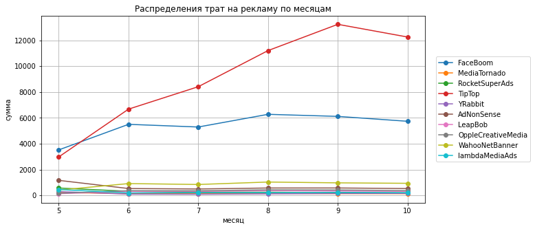

```python
costs_month = (
    costs_dt.pivot_table(index='month',columns='channel', values='costs', aggfunc='sum')
    .plot(
        y=list(costs_dt['channel'].unique()),
        style='o-',
        grid=True,
        figsize=(10, 5),
        title='Распределения трат на рекламу по месяцам',
    )
)

costs_month.set_xlabel('месяц')
costs_month.set_ylabel('сумма')
plt.legend(loc='center left', bbox_to_anchor=(1.02, 0.5));#вынос легенды за пределы таблицы

plt.show()
```

Наблюдаем как росли расходы с мая по октябрь, видно как выросли траты на два канала:

Построим недельный график для более детальной визуализации:

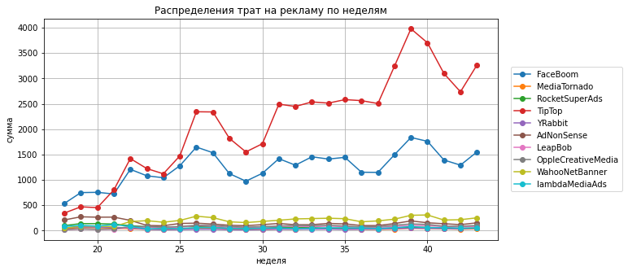

```python
costs_week = (
    costs_dt.pivot_table(index='week',columns='channel', values='costs', aggfunc='sum')
    .plot(
        y=list(costs_dt['channel'].unique()),
        style='o-',
        grid=True,
        figsize=(10, 5),
        title='Распределения трат на рекламу по неделям',
    )
)

costs_week.set_xlabel('неделя')
costs_week.set_ylabel('сумма')
plt.legend(loc='center left', bbox_to_anchor=(1.02, 0.5));#вынос легенды за пределы таблицы

plt.show()
```

На графике видим примерно такуе же картину, только менее сглаженую.

Посмотрим сколько в среднем стоило привлечение одного пользователя (CAC) из каждого источника:

```python
cac_users = (
    users.groupby('channel')
    .agg({'acquisition_cost':'mean'})
    .sort_values('acquisition_cost')
    .reset_index()
)
cac_users
```

|  | channel | acquisition_cost |
| --- | --- | --- |
| 0 | organic | 0.000000 |
| 1 | LeapBob | 0.210172 |
| 2 | MediaTornado | 0.218717 |
| 3 | YRabbit | 0.218975 |
| 4 | OppleCreativeMedia | 0.250000 |
| 5 | RocketSuperAds | 0.412095 |
| 6 | WahooNetBanner | 0.602245 |
| 7 | lambdaMediaAds | 0.724802 |
| 8 | AdNonSense | 1.008054 |
| 9 | FaceBoom | 1.113286 |
| 10 | TipTop | 2.799003 |

Топ каналов привлечения минимальных затрат на одного пользователя:

- Самый недорогой канал привлечения это `LeapBob` всего *0.21* в среднем за одного пользователя
- Далее идет канал `MediaTornado` стоит *0.22* в среднем за одного пользователя
- Замыкает тройку `YRabbit` стоит *0.22* в среднем за одного пользователя

Антилидеры:

- Самый дорогой канал привлечения это `TipTop` всего *2.8* в среднем за одного пользователя
- Далее идет канал `FaceBoom` стоит *1.1* в среднем за одного пользователя
- Замыкает тройку `AdNonSense` стоит *1* в среднем за одного пользователя

### Оценим окупаемость рекламы

Используя графики LTV, ROI и CAC, проанализируем окупаемость рекламы. Зададим момент анализа и горизонт анализа:

```python
observation_date = datetime(2019, 11, 1).date()  # момент анализа
horizon_days = 14  # горизонт анализа
```

вызовим функции `get_ltv` и `plot_ltv_roi` для построения графиков **LTV** и **ROI**, а также графики динамики **LTV, CAC и ROI.**

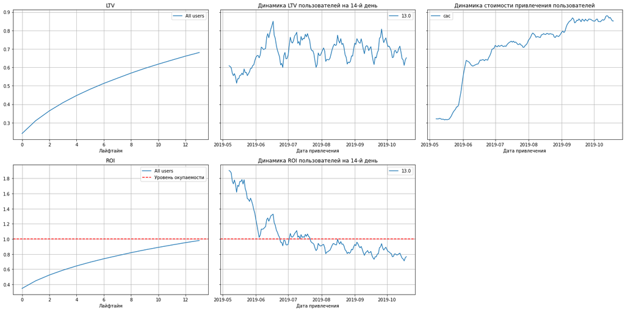

```python
# посчитаем LTV и ROI
ltv_raw, ltv_grouped, ltv_history, roi_grouped, roi_history = get_ltv(
    users, orders, observation_date, horizon_days
)

# построим графики
plot_ltv_roi(ltv_grouped, ltv_history, roi_grouped, roi_history, horizon_days)
```

По графикам можно сделать выводы:

- Реклама почти окупается, `ROI` в конце второй недели **98%**
- По динамике `ROI` видно как падает график видно влияние увеличения рекламного бюджета.
- `CAC` интенсивно увеличивается, бюджет сильно вырос с мая по октябрь.
- динамика `LTV` изменяется но все примерно в одном корридоре, значит дело не в ухудшении качества пользователей.

Уберем пользователей которые пришли без рекламы(`organic`) чтобы исключить их влияние:

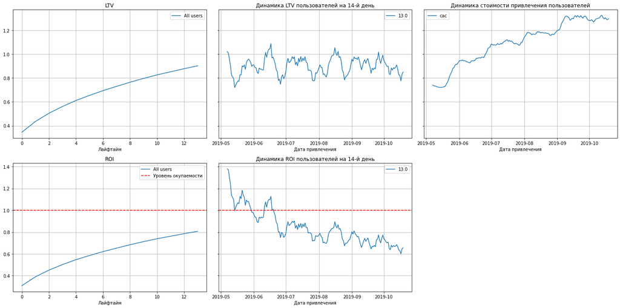

```python
users_no_organic = users.query('channel !="organic"')

# посчитаем LTV и ROI
ltv_raw, ltv_grouped, ltv_history, roi_grouped, roi_history = get_ltv(
    users_no_organic, orders, observation_date, horizon_days
)

# построим графики
plot_ltv_roi(ltv_grouped, ltv_history, roi_grouped, roi_history, horizon_days)
```

- Без пользователей которые пришли сами, показатель ROI опустился до **80%**.
- LTV с `organic` он был почти **0,7**, без увеличился до **0,9**
- CAC так же вырос

Посмотрим общюю конверсию и удержание:

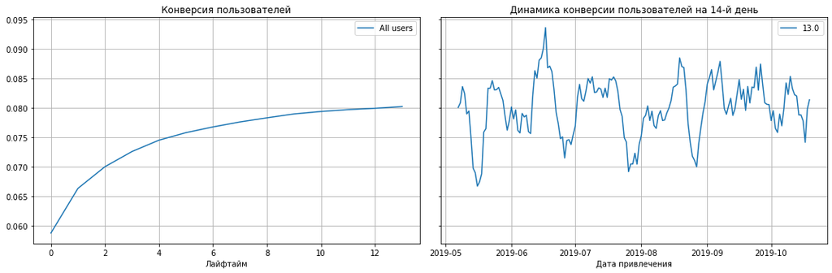

```python
#конверсия

conversion_raw, conversion_grouped, conversion_history = get_conversion(
    users_no_organic, orders, observation_date, horizon_days
)

plot_conversion(conversion_grouped, conversion_history, horizon_days)
```

Все выглядит хорошо, хоть и до единицы нашей кривой еще далеко, перейдем к удержанию:

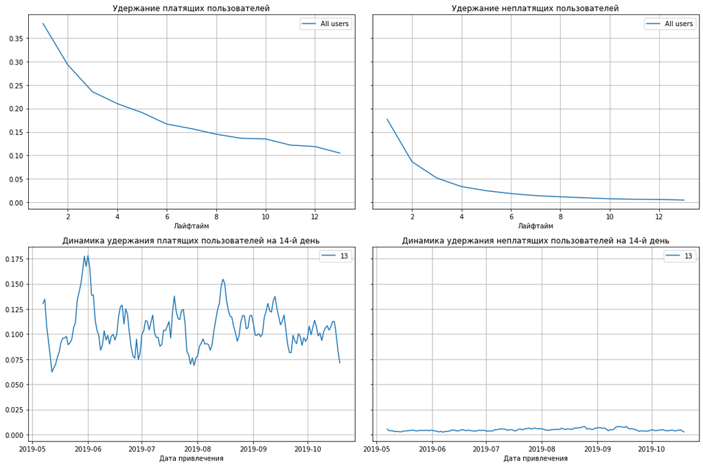

```python
#удержание

retention_raw, retention_grouped, retention_history = get_retention(
    users_no_organic, sessions, observation_date, horizon_days
)

plot_retention(retention_grouped, retention_history, horizon_days)
```

Похоже на общем фоне все в порядке.

- кривая удержания платящих пользователей выше, чем неплатящих,
- обе кривые постепенно снижаются.

Чтобы разобраться посмотрим другие доступные характеристики пользователей с разделением по: **стране**, **источнику** и **устройству**

Посмотрим разбивку по устройствам:

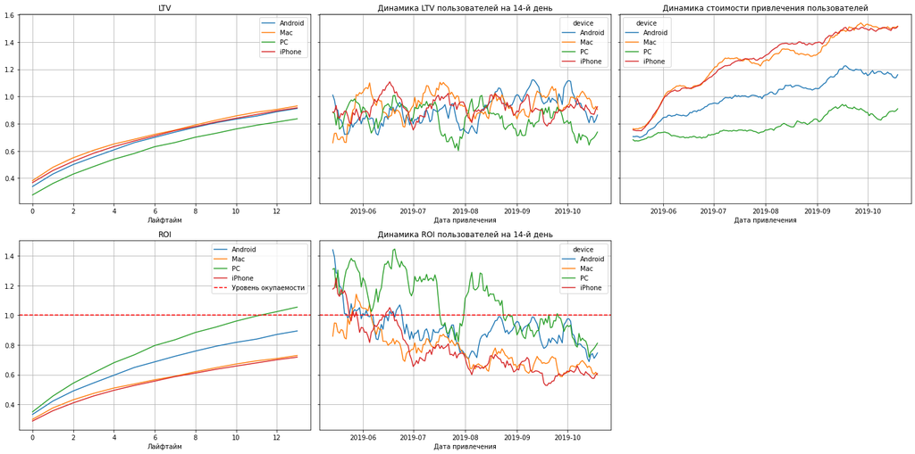

```python
dimensions = ['device']

ltv_raw, ltv_grouped, ltv_history, roi_grouped, roi_history = get_ltv(
    users_no_organic, orders, observation_date, horizon_days, dimensions=dimensions
)

plot_ltv_roi(
    ltv_grouped, ltv_history, roi_grouped, roi_history, horizon_days, window=14
)
```

С разбивкой тоже не все хорошо, но есть и хороший момент:

- зашедшие с `PC` окупаются за две недели, чуть переодолев **105%**.
- стоимость привлечения сильно различается по устройствам - `PC` самая стабильная, `Mac` и `iPhone` выросли почти в 2 раза, `Android` в 1,5 раза.
- LTV всё так же подвержен сезонности, но стабилен.
- Динамика 14 дня `ROI` показывает что вся реклама постепенно снижается и не окупается уже с начала сентября. Есть Провал во второй половине июля.(только у `PC`)

Посмотрим разбивку по странам:

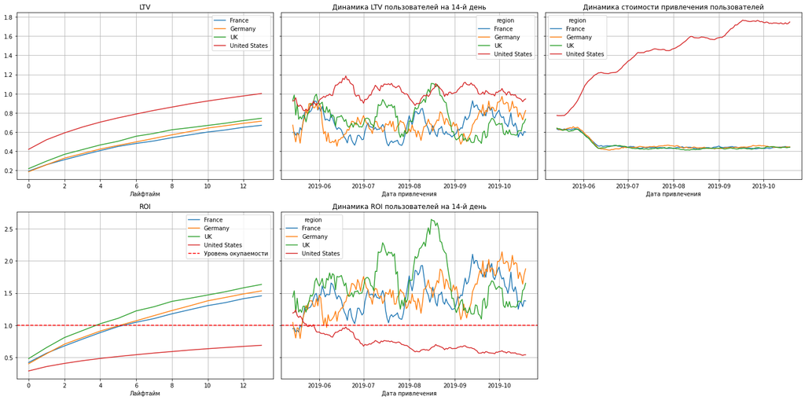

```python
dimensions = ['region']

ltv_raw, ltv_grouped, ltv_history, roi_grouped, roi_history = get_ltv(
    users_no_organic, orders, observation_date, horizon_days, dimensions=dimensions
)

plot_ltv_roi(
    ltv_grouped, ltv_history, roi_grouped, roi_history, horizon_days, window=14
)
```

По странам картина выглядит гораздо лучше:

- Все регионы окупаются уже к концу первой недели и к концу второй недели показывают **150%**, кроме `United States` не оккупается и показывает **70%**.
- По LTV видно что `United States` имеют более высокий показатель.
- По динамике привлечение видно как сильно растет стоимость из `United States`, а по другим странам наоборот стоимоть в конце мая начинает падать, и дальше показываает стабильность.
- Динамика 14 дня `ROI` так же подтверждает другие показатели окупаемость из `United States` снижается, а из других стран есть сезонные колебания но в целом все положительно.

Посмотрим разбивку по каналам привлечения:

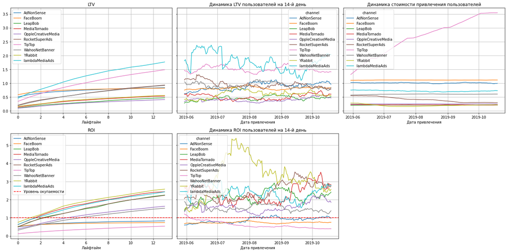

```python
dimensions = ['channel']

ltv_raw, ltv_grouped, ltv_history, roi_grouped, roi_history = get_ltv(
    users_no_organic, orders, observation_date, horizon_days, dimensions=dimensions
)

plot_ltv_roi(
    ltv_grouped, ltv_history, roi_grouped, roi_history, horizon_days, window=30
)
```

Выводы по каналам привлечения:

- Не оккупаются каналы `TipTop`, `FaceBoom` и `AdNonSense`.
- По динамике стоимости привлечение видно как сильно растет стоимость канала`TipTop`, другие каналы показывают стабильность.
- Лидеры по `ROI` это каналы `YRabbit`, `MediaTornado` и `lambdaMediaAds`.

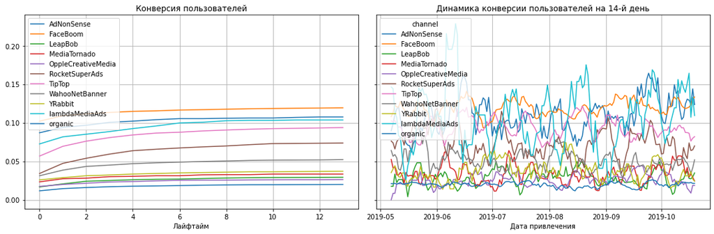

```python
#конверсия с разбивкой по каналам

conversion_raw, conversion_grouped, conversion_history = get_conversion(
    users, orders, observation_date, horizon_days, dimensions=dimensions
)

plot_conversion(conversion_grouped, conversion_history, horizon_days)
```

С конверсией все нормально, посмотрим удержание по каналам:

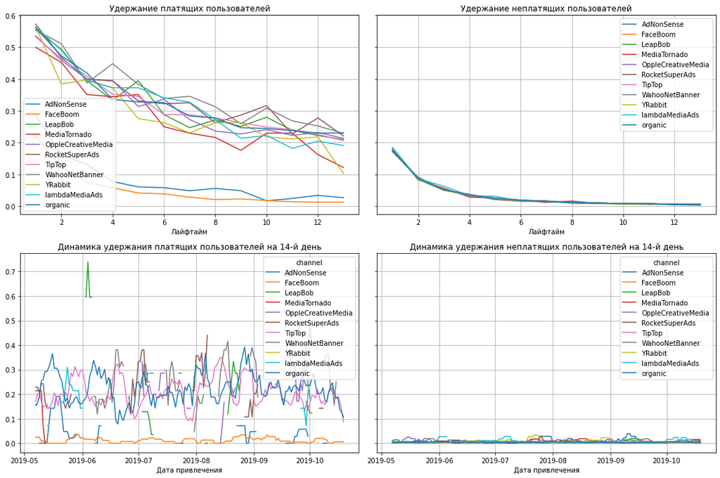

```python
#удержание с разбивкой по каналам

retention_raw, retention_grouped, retention_history = get_retention(
    users, sessions, observation_date, horizon_days, dimensions=dimensions
)

plot_retention(retention_grouped, retention_history, horizon_days)
```

Видно что каналы `FaceBoom` и `AdNonSense` плохо удерживаются. Для платящих пользователей удержание 7-го дня ниже, чем на остальных каналах, примерно на 20%.

Посмотрим распределение каналов по регионам:

```python
region_channel = (
    users.groupby(['region','channel'])
    .agg({'channel':'count'})
    .rename(columns={'channel': 'counts'}) # переменовываем колонки
    .sort_values(['region','counts'],ascending=False)
)
region_channel
```

| region | channel | counts |
| --- | --- | --- |
| United States | organic | 38173 |
|  | FaceBoom | 29144 |
|  | TipTop | 19561 |
|  | RocketSuperAds | 4448 |
|  | MediaTornado | 4364 |
|  | YRabbit | 4312 |
| UK | organic | 6421 |
|  | OppleCreativeMedia | 3052 |
|  | LeapBob | 3046 |
|  | WahooNetBanner | 3003 |
|  | AdNonSense | 1295 |
|  | lambdaMediaAds | 758 |
| Germany | organic | 5453 |
|  | WahooNetBanner | 2579 |
|  | OppleCreativeMedia | 2562 |
|  | LeapBob | 2519 |
|  | AdNonSense | 1219 |
|  | lambdaMediaAds | 649 |
| France | organic | 6392 |
|  | OppleCreativeMedia | 2991 |
|  | LeapBob | 2988 |
|  | WahooNetBanner | 2971 |
|  | AdNonSense | 1366 |
|  | lambdaMediaAds | 742 |

Два самых крупных канала привлечения относятся к региону `United States` (`FaceBoom` и `TipTop`) и они не оккупают себя. Канал `AdNonSense` так же не оккупивший себя распределен между тремя регионами `UK`, `France` и `Germany`.

Проверим если уберем самый затратный канал `TipTop` как изменится оккупаемость по регионам и устройствам:

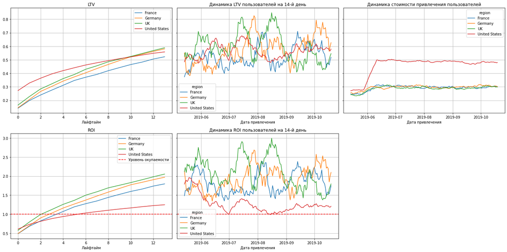

```python
users_no_tiptop = users.query('channel !="TipTop"')

dimensions = ['region']

ltv_raw, ltv_grouped, ltv_history, roi_grouped, roi_history = get_ltv(
    users_no_tiptop, orders, observation_date, horizon_days, dimensions=dimensions
)

plot_ltv_roi(
    ltv_grouped, ltv_history, roi_grouped, roi_history, horizon_days, window=14
)
```

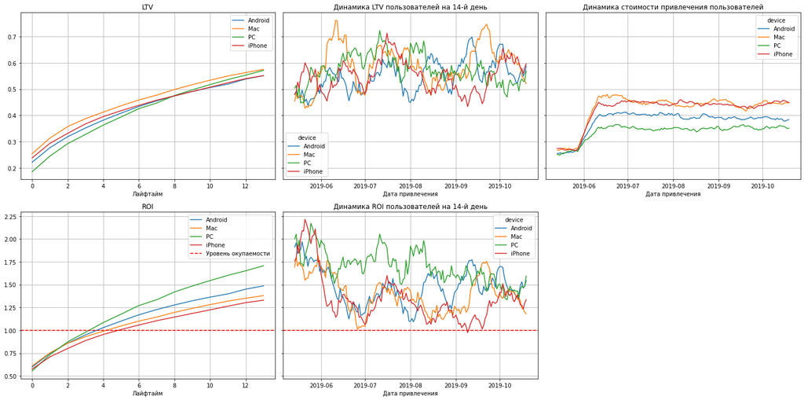

```python
dimensions = ['device']

ltv_raw, ltv_grouped, ltv_history, roi_grouped, roi_history = get_ltv(
    users_no_tiptop, orders, observation_date, horizon_days, dimensions=dimensions
)

plot_ltv_roi(
    ltv_grouped, ltv_history, roi_grouped, roi_history, horizon_days, window=14
)
```

Видимо действительно виной выросшие расходы на канал привлечение `TipTop` который все равно не оккупается.